# Predicting Accuracy Of Barbell Lifts Exercise Using Accelerometer Data

Chidambaranathan Kavitha

22 June 2017

## Executive Summary:

Data from accelerometers on the belt, forearm, arm, and dumbell of 6 participants are provided. They were asked to do the barbell lifts accurately and inaccurately in five different ways. The goal is to predict the manner in which the exercise was done. The “classe” variable is the outcome while all other variables can be used as predictors.

## Data

Separate sets of training and testing data were provided by http://groupware.les.inf.puc-rio.br/har.

Training data set can be downloaded from https://d396qusza40orc.cloudfront.net/predmachlearn/pml-training.csv

Testing data set can be downloaded from https://d396qusza40orc.cloudfront.net/predmachlearn/pml-testing.csv

## Data Analysis and Cleansing

Initial viewing of the csv data brought a few facts to light immediately.

[, 1] Several columns had NA values for all the rows [, 2] There was a row identifier column with a sequential number as the first column. [, 3] A few more columns with data such as name of participant, timestamp columns etc. that have no value as predictors.

Load required libraries and read the csv data to memory

```r
library(readr)
library(caret)
```

```r
library(rpart)
library(rpart.plot)
library(rattle)
library(RColorBrewer)
library(randomForest)
training <- read.csv("C:/Users/chidakav/Downloads/pml-training.csv", sep=",", header=TRUE, na.strings = c("NA", "#DIV/0!"))
testing <- read.csv("C:/Users/chidakav/Downloads/pml-testing.csv",sep=",", header=TRUE, na.strings = c("NA", "#DIV/0!"))
```

Prepare the data to remove the NA columns, and the columns identified as not useful.

```r
training <- training[, colSums(is.na(training)) == 0]
testing <- testing[, colSums(is.na(testing)) == 0]

training <- training[, - c(1,2,3,4,5,6,7)]
testing <- testing[, - c(1,2,3,4,5,6,7)]
```

We removed the first seven columns as they do not contribute as a predictor in any useful way.

## Pre-process Data

Pre-process the data with the center and scale methods. Set a seed value to ensure reproducibility.

```r
set.seed(12396)
preProcValues <- preProcess(training, method = c("center", "scale"))

Proctrain <- predict(preProcValues, training)
Proctrain$classe <- training$classe

Proctest <- predict(preProcValues, testing)
```

## Data Partition

Partition the training set into a training and validation set.

```r
inTrain <- createDataPartition(Proctrain$classe, p = 0.7, list = FALSE)
Dttrain <- Proctrain[inTrain, ]
Dtvalid <- Proctrain[-inTrain, ]

dim(Dttrain)
```

```
## [1] 13737    53
```

```r
dim(Dtvalid)
```

```
## [1] 5885   53
```

## Prediction Models

We can consider the Classification Tree and the RandomForest Analysis models to build a prediction model. The final selection will however be based on the accuracy returned by these models.

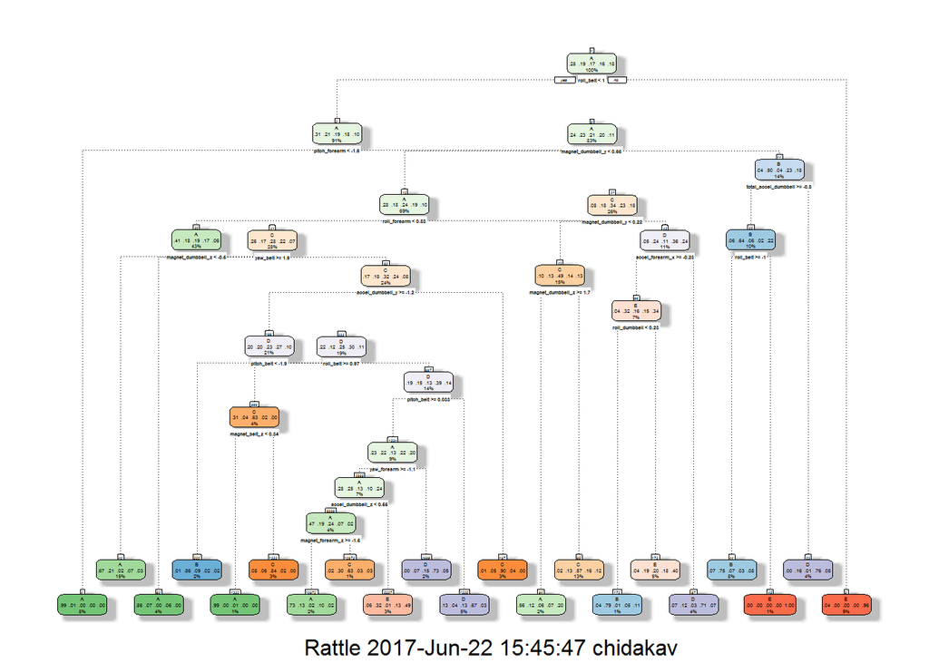

```r
modFit_class <- rpart(classe ~ ., data=Dttrain, method="class")
fancyRpartPlot(modFit_class)
```

Let’s predict this data against the validation set to check the accuracy level

```r
pred_class <- predict(modFit_class , Dtvalid, type = "class")
conf_class <- confusionMatrix(Dtvalid$classe,pred_class )
print(conf_class)
```

```
## Confusion Matrix and Statistics
##
##           Reference
## Prediction    A    B    C    D    E
##          A 1486   34   38   54   62
##          B  262  532  132   71  142
##          C   35   40  813   68   70
##          D  139   28  134  584   79
##          E   68   52  107   54  801
##
## Overall Statistics
##
##                Accuracy : 0.7164
##                  95% CI : (0.7047, 0.7279)
##     No Information Rate : 0.3381
##     P-Value [Acc > NIR] : < 2.2e-16
##
##                   Kappa : 0.6391
##  Mcnemar's Test P-Value : < 2.2e-16
##
## Statistics by Class:
##
##                      Class: A Class: B Class: C Class: D Class: E
## Sensitivity            0.7467   0.7755   0.6642  0.70277   0.6941
## Specificity            0.9517   0.8832   0.9543  0.92481   0.9406
## Pos Pred Value         0.8877   0.4671   0.7924  0.60581   0.7403
## Neg Pred Value         0.8803   0.9676   0.9154  0.94981   0.9265
## Prevalence             0.3381   0.1166   0.2080  0.14121   0.1961
## Detection Rate         0.2525   0.0904   0.1381  0.09924   0.1361
## Detection Prevalence   0.2845   0.1935   0.1743  0.16381   0.1839
## Balanced Accuracy      0.8492   0.8294   0.8093  0.81379   0.8174
```

Only 71% accuracy is seen using the classification prediction model.

Next trial is using the RandomForest which usually gives a better accuracy rate.

```r
modFit_rf <- randomForest(classe ~. , data=Dttrain)
pred_rf <- predict(modFit_rf, Dtvalid, type = "class")
conf_rf <- confusionMatrix(Dtvalid$classe,pred_rf )
print(conf_rf)
```

```
## Confusion Matrix and Statistics
##
##           Reference
## Prediction    A    B    C    D    E
##          A 1666    5    0    0    3
##          B    7 1129    3    0    0
##          C    0    2 1022    2    0
##          D    0    0    2  961    1
##          E    0    0    0    5 1077
##
## Overall Statistics
##
##                Accuracy : 0.9949
##                  95% CI : (0.9927, 0.9966)
##     No Information Rate : 0.2843
##     P-Value [Acc > NIR] : < 2.2e-16
##
##                   Kappa : 0.9936
##  Mcnemar's Test P-Value : NA
##
## Statistics by Class:
##
##                      Class: A Class: B Class: C Class: D Class: E
## Sensitivity            0.9958   0.9938   0.9951   0.9928   0.9963
## Specificity            0.9981   0.9979   0.9992   0.9994   0.9990
## Pos Pred Value         0.9952   0.9912   0.9961   0.9969   0.9954
## Neg Pred Value         0.9983   0.9985   0.9990   0.9986   0.9992
## Prevalence             0.2843   0.1930   0.1745   0.1645   0.1837
## Detection Rate         0.2831   0.1918   0.1737   0.1633   0.1830
## Detection Prevalence   0.2845   0.1935   0.1743   0.1638   0.1839
## Balanced Accuracy      0.9970   0.9959   0.9972   0.9961   0.9976
```

The results have a near accurate prediction rate of 99.5%. So the out-of-sample error is 0.5%.

Using the RandomForest prediction model modFit_rf, we proceed to do the prediction of the untouched test data.

## Predicted Results using RandomForest Model.

```r
predict(modFit_rf, Proctest, type = "class")
```

```
##  1  2  3  4  5  6  7  8  9 10 11 12 13 14 15 16 17 18 19 20
##  B  A  B  A  A  E  D  B  A  A  B  C  B  A  E  E  A  B  B  B
## Levels: A B C D E
```